# Cinema Tickets clustering analysis

## Clustering of the dataset

### Checking the clustering tendancy of the dataset

```r
names(finaldata)
```

```
##  [1] "city"         "show_time"    "occu_perc"    "ticket_price" "ticket_use"
##  [6] "capacity"     "month"        "quarter"      "day"          "total_sales"
```

```r
finaldata<-finaldata[,2:10]
clusterable <- get_clust_tendency(finaldata, n = nrow(finaldata)-1, graph = FALSE)
clusterable$hopkins_stat
```

```
## [1] 0.9371886
```

### Finding optimal number of clusters

To find optimal number of clusters, different methods would be used to compare and come up with the best result.

#### Using Silhoutte statistic

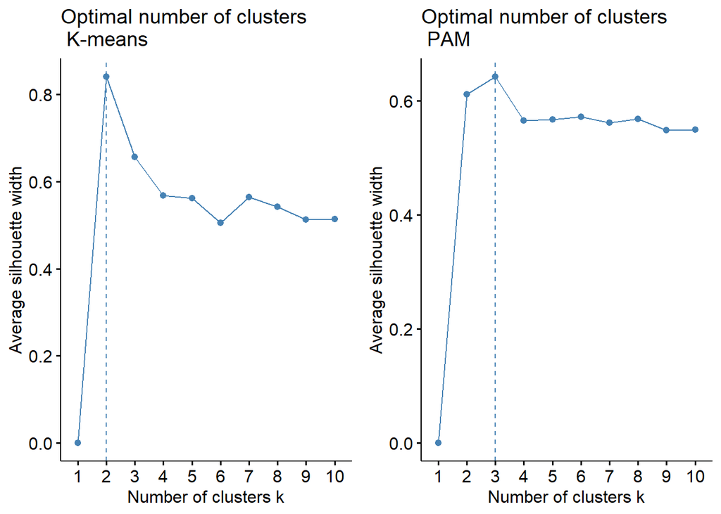

```r
f1 <- fviz_nbclust(finaldata, FUNcluster = kmeans, method = "silhouette") +
  ggtitle("Optimal number of clusters \n K-means")

f2 <- fviz_nbclust(finaldata, FUNcluster = cluster::pam, method = "silhouette") +
  ggtitle("Optimal number of clusters \n PAM")

grid.arrange(f1, f2, ncol=2)
```

#### Using total Within Sum of Squares of clusters statistics

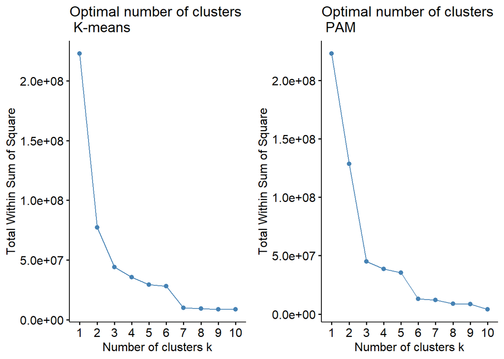

```r
f3 <- fviz_nbclust(finaldata, FUNcluster = kmeans, method = "wss") +
  ggtitle("Optimal number of clusters \n K-means")

f4 <- fviz_nbclust(finaldata, FUNcluster = cluster::pam, method = "wss") +
  ggtitle("Optimal number of clusters \n PAM")

grid.arrange(f3, f4, ncol=2)
```

Now, this plot is a bit complicated as there is no obvious answer as to how many clusters would be ideal. Visualizing the plot properly, one can argue if 2 or more clusters should be used. although the probabilities of getting meaningful classification in more than 2 clusters is very low, this can be considered.

#### Using Elbow method

```r
k_max <- 10

wss <- sapply(1:k_max, function(k){kmeans(finaldata, k,
                                          nstart=50,iter.max = 1000 )$tot.withinss})

wss
```

```
##  [1] 222898052  77127061  43980353  20390561  29430301  10895441   9852586
##  [8]   9037770   7324864   7059948
```

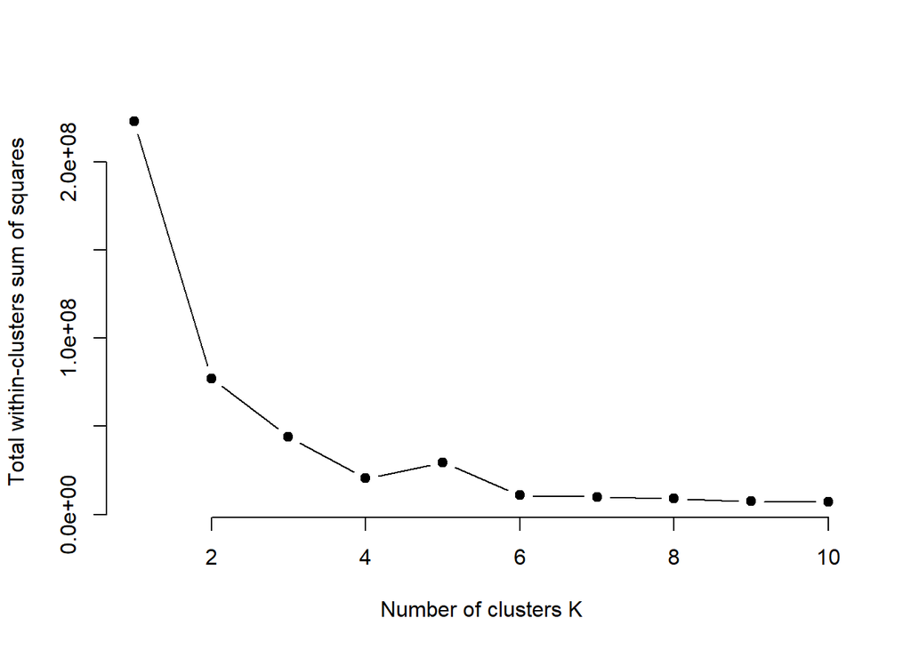

```r
plot(1:k_max, wss,
     type="b", pch = 19, frame = FALSE,
     xlab="Number of clusters K",
     ylab="Total within-clusters sum of squares")
```

This plot further emphasises that the number of clusters should be 2 for the dataset as the elbow appears at 2.

### K-means clustering

#### Considering 2 clusters

```r
kmean2 <- eclust(finaldata, k=2 , FUNcluster="kmeans", hc_metric="euclidean", graph=F)

cluster2 <- fviz_cluster(kmean2, finaldata, elipse.type="convex", geom=c("point")) + ggtitle("K-means with 2 clusters")

sil2 <- fviz_silhouette(kmean2)
```

```
##   cluster size ave.sil.width
## 1       1  290          0.86
## 2       2   15          0.55
```

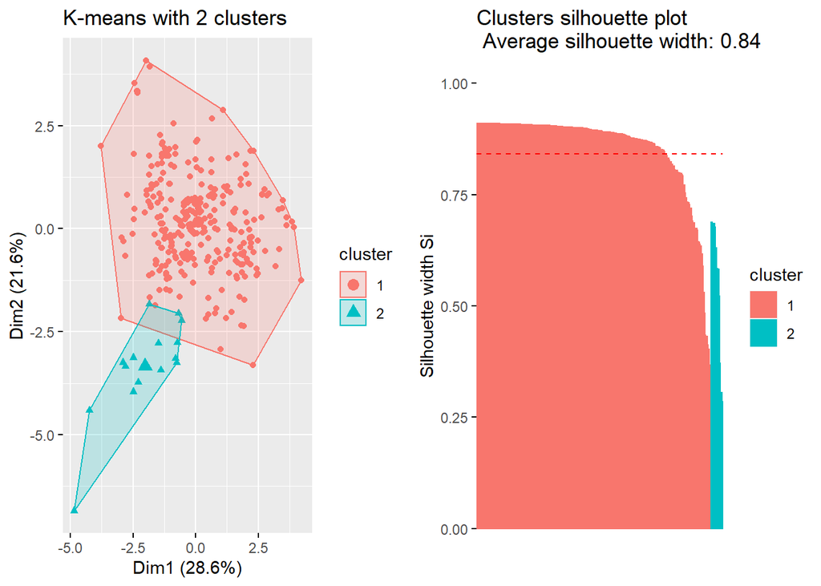

```r
grid.arrange(cluster2, sil2, ncol=2)
```

As we can see, the data is highly homogenous. the clustering exercise is not highly useful for this kind of dataset. however considering the 2 clusters, and the above graph, we cannot get more clusters from the above dataset.

**The above outputs suggest that the above clustering based on only 2 clusters is a best possible fit for the dataset as the average silhouette width for both the clusters is positive. This means the points in both the clusters are clustered properly. This is ithe conclusion which was reached after having tried several clustering techniques and several clustering methodologies. Those examples are added as an Appendix to the main Dimension Reduction and Clustering exercise above.**

The other clusters suggested by the k-means will be tried below:

## Considering several other clustering exercises after the dimentions are selected above.

#### Considering 5 clusters

```r
kmean5 <- eclust(finaldata, k=5 , FUNcluster="kmeans", hc_metric="euclidean", graph=F)

cluster5 <- fviz_cluster(kmean5, finaldata, elipse.type="convex", geom=c("point")) + ggtitle("K-means with 5 clusters")

sil5 <- fviz_silhouette(kmean5)
```

```
##   cluster size ave.sil.width
## 1       1  134          0.65
## 2       2   99          0.52
## 3       3   13          0.29
## 4       4    9          0.27
## 5       5   50          0.53
```

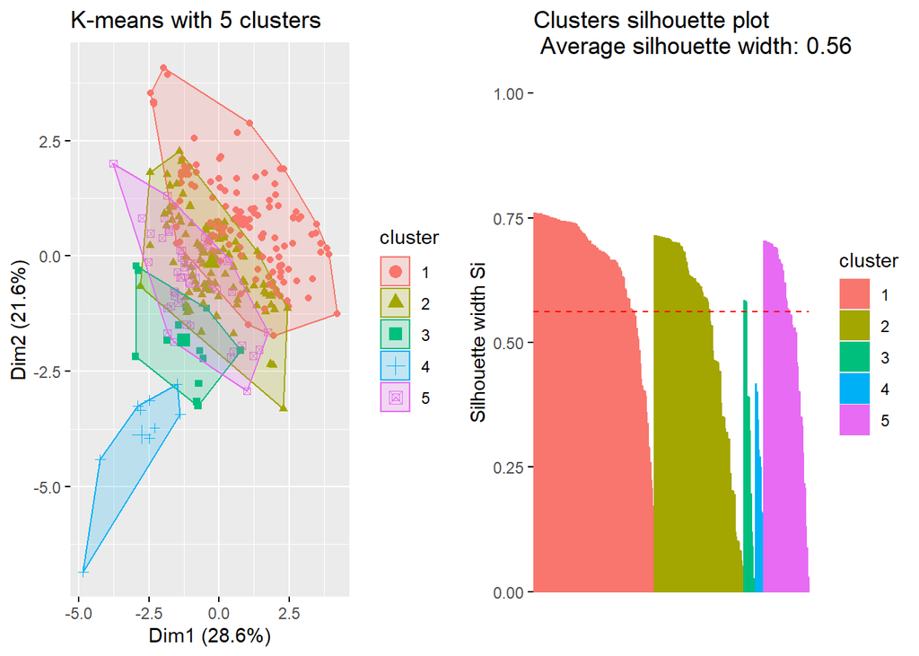

```r
grid.arrange(cluster5, sil5, ncol=2)
```

#### Considering 3 clusters

```r
kmean3 <- eclust(finaldata, k=3 , FUNcluster="kmeans", hc_metric="euclidean", graph=F)

cluster3 <- fviz_cluster(kmean3, finaldata, elipse.type="convex", geom=c("point")) + ggtitle("K-means with 3 clusters")

sil3 <- fviz_silhouette(kmean3)
```

```
##   cluster size ave.sil.width
## 1       1  221          0.73
## 2       2   72          0.47
## 3       3   12          0.51
```

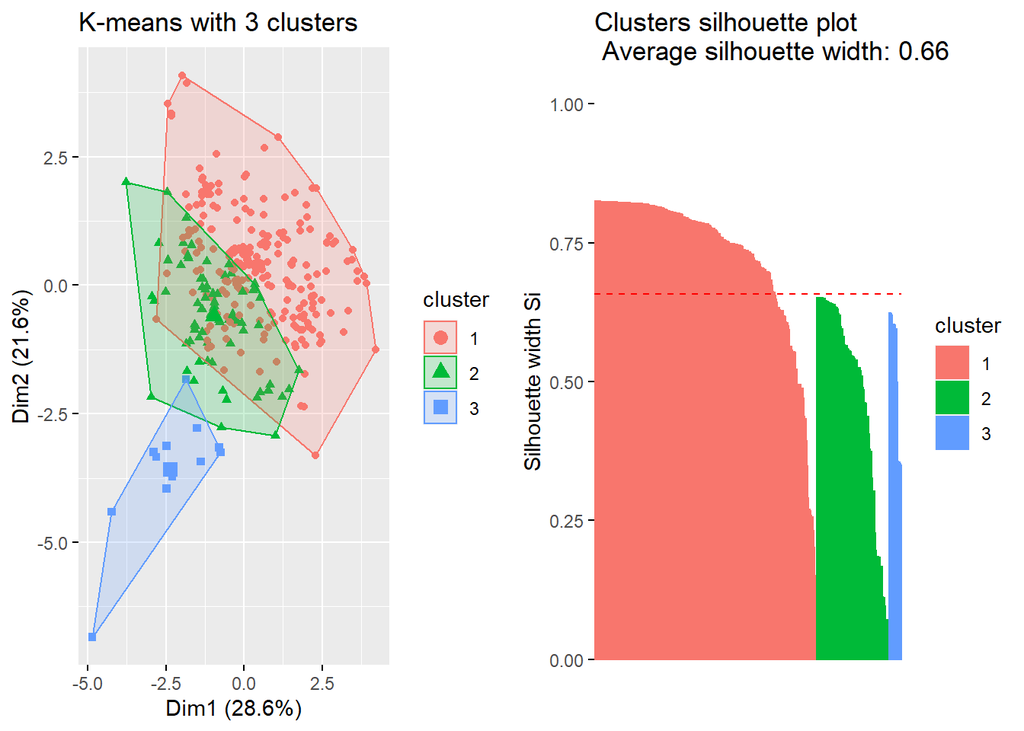

```r
grid.arrange(cluster3, sil3, ncol=2)
```

The above results and plots clearly suggest that there is some serious overlapping of clusters which is not a great thing. It means out of all these possibilties given by K-means algorithm, classifying the countries into 2 clusters would be the best idea.

Let’s now use PAM algorithm to check what results does it gives.

### PAM clustering

#### Considering 2 clusters

```r
pam2 <- eclust(finaldata, k=2 , FUNcluster="pam", hc_metric="euclidean", graph=F)

cpam2 <- fviz_cluster(pam2, finaldata, elipse.type="convex", geom=c("point")) + ggtitle("PAM with 2 clusters")

silpam2 <- fviz_silhouette(pam2)
```

```
##   cluster size ave.sil.width
## 1       1  220          0.82
## 2       2   85          0.06
```

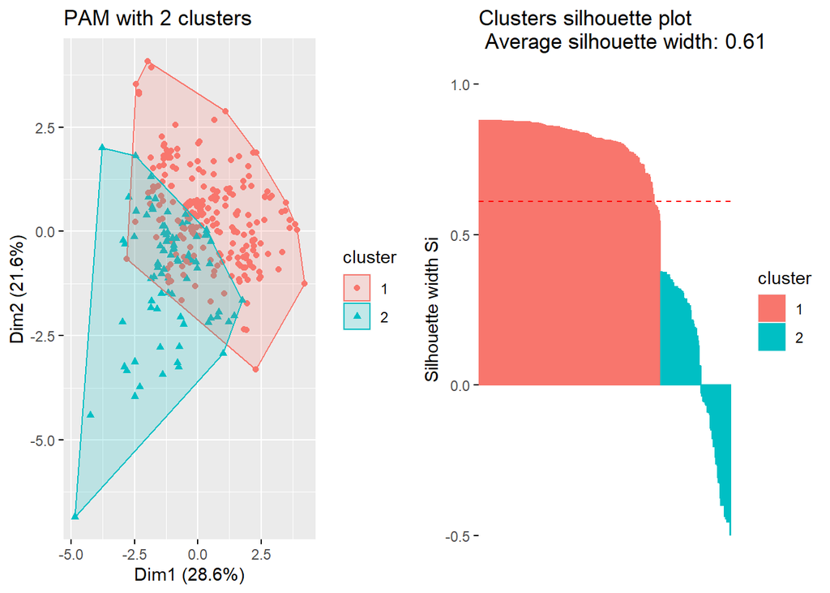

```r
grid.arrange(cpam2, silpam2, ncol=2)
```

#### Considering 5 clusters

```r
pam5 <- eclust(finaldata, k=5 , FUNcluster="pam", hc_metric="euclidean", graph=F)

cpam5 <- fviz_cluster(pam5, finaldata, elipse.type="convex", geom=c("point")) + ggtitle("PAM with 5 clusters")

silpam5 <- fviz_silhouette(pam5)
```

```
##   cluster size ave.sil.width
## 1       1  130          0.58
## 2       2   32          0.49
## 3       3   82          0.61
## 4       4   15          0.34
## 5       5   46          0.56
```

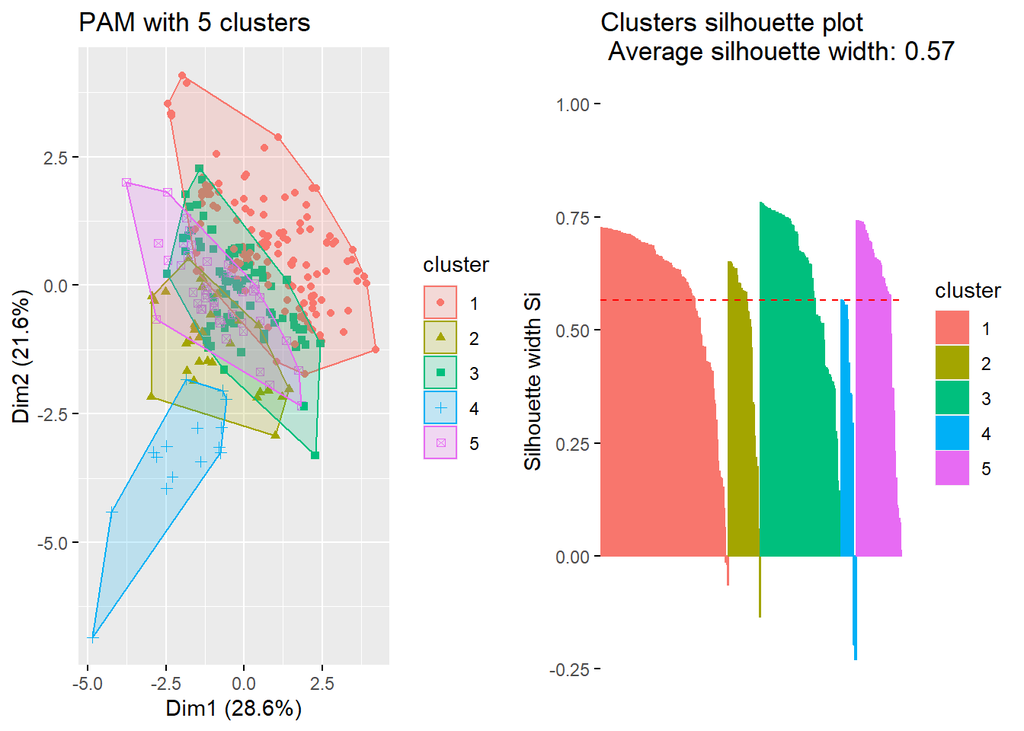

```r
grid.arrange(cpam5, silpam5, ncol=2)
```

Clearly, the result suggest it is not a bad idea to consider 5 clusters but the presence of overlapping as seen in the plot and also the negative silhouette width for some countries suggest it would be better to consider more options.

#### Considering 3 clusters

```r
pam3 <- eclust(finaldata, k=3 , FUNcluster="pam", hc_metric="euclidean", graph=F)

cpam3 <- fviz_cluster(pam3, finaldata, elipse.type="convex", geom=c("point")) + ggtitle("PAM with 3 clusters")

silpam3 <- fviz_silhouette(pam3)
```

```
##   cluster size ave.sil.width
## 1       1  210          0.72
## 2       2   80          0.48
## 3       3   15          0.44
```

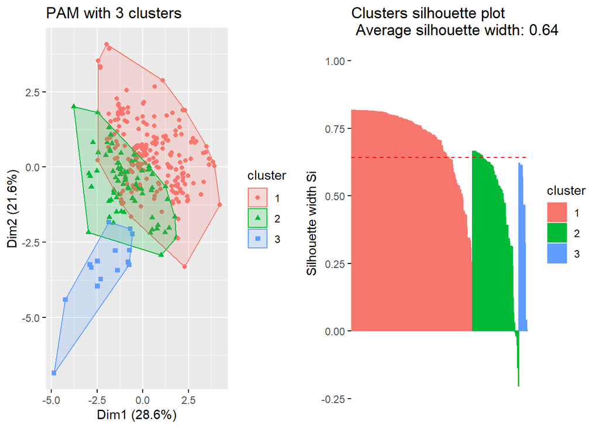

```r
grid.arrange(cpam3, silpam3, ncol=2)
```

Again, the same issue of overlapping exist in this case. Considering all the options, using 2 clusters seems to be the best option.

### Conclusion:

The exercise above suggests that almost all variables namely have the major contributions. This can be accepted as this is movie ticket sales data from 2018 when consumer spending was in full swing.

Apart from this, if I tried to get more clusters from the dataset, then the clusters were operlapping eachother. this is because, as explained, the data is highly homogenous. Even the “PAM with 2 clusters”, is not very useful.

However, since it is a data over the year of 2018, one would have expected a seasonality in terms of the movie sales and some type of clustering or trend.

### References:

1. https://rpubs.com/asmi2990/732488
2. https://www.rdocumentation.org/packages/stats/versions/3.6.2/topics/cor
3. 1. https://en.wikipedia.org/wiki/Hierarchical_clustering